# Reproducible results : Course project 1

# Now we look at the mean and medians of both files : the one with and the one without the NA values

```r
summary(activimputeday)
```

```
##    Min. 1st Qu.  Median    Mean 3rd Qu.    Max.
##      41    9819   10766   10766   12811   21194
```

```r
summary(actividay)
```

```
##    Min. 1st Qu.  Median    Mean 3rd Qu.    Max.    NA's
##      42    8842   10766   10767   13295   21195       8
```

There is very little difference

# Comparison histogram with and without impute

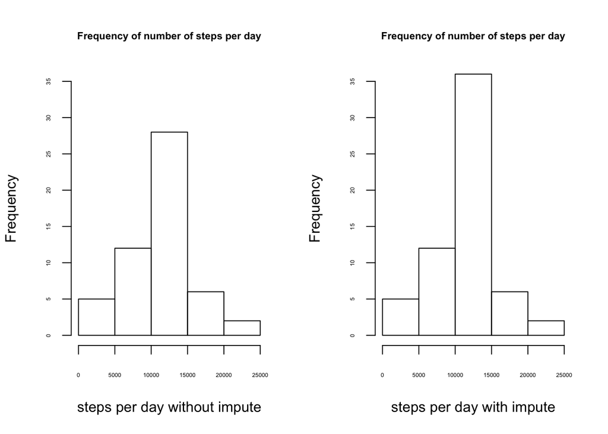

```r
par(mfrow=c(1,2))
hist(actividay,cex.axis=0.7,cex.axis=0.4,labels=5,xlab="steps per day without impute",
     main="Frequency of number of steps per day",cex.main=0.7,ylim = c(0,35))
hist(activimputeday,cex.axis=0.7,cex.axis=0.4,labels=5,xlab="steps per day with impute",
     main="Frequency of number of steps per day",cex.main=0.7,ylim = c(0,35))
```

Here we do see a difference : the frequency of the 10-15k break in the histogram has gone up. We have more average values, which is,I guess caused by our imputation strategy.this also explains why the mean and median have hardly changed

## Are there differences in activity patterns between weekdays and weekends?

# New factor variable to indicate the weekday or weekend

```r
activimpute$weekday<-weekdays(as.Date(activimpute$date))
library(dplyr)
activimpute<-activimpute %>%
                mutate(daytype=ifelse(weekdays(as.Date(date)) %in%
                c("Sunday","Saturday"),"weekend","week"))
```

The new column is called “daytype” and contains “weekend” for a weekend day and “week” for a weekday

# Averaging across all days per interval and split by weekend and week

```r
columns<-c("daytype","interval")
library(dplyr)
activimputetime<-activimpute %>%
        group_by_at(vars(one_of(columns))) %>%
        summarize(stepsmean= mean(steps))
```

# plotting week against weekend

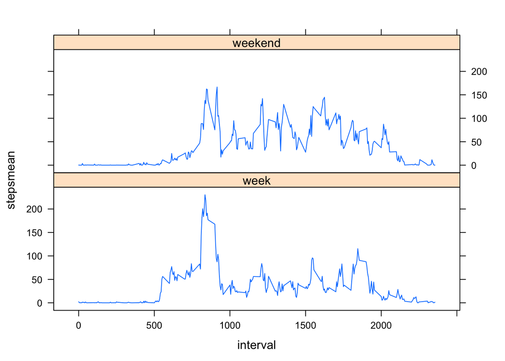

```r
library(lattice)

xyplot(stepsmean ~ interval | daytype, data=activimputetime,type="l",layout=c(1,2))
```

We see that for weekdays, the peaks of the activity can be found in the morning and in the evening. On weekend days, things are a bit more distributed without having these 2 peaks. Logical!